# Day 2 code

Author

Constantin Manuel Bosancianu

Published

January 21, 2021

# 1 Introduction

We start in the same way as yesterday - by loading needed packages, and reading in the data.

```r
library(pacman)
p_load(tidyverse, broom, ggeffects, texreg, arm,
       broom.mixed, ggthemes, interplot, knitr)
```

# 2 Reading data

```r
df_issp <- readRDS("../02-data/01-ISSP.rds")
```

```r
df_issp <- df_issp %>%
    dplyr::select(cnt, year, country, poleff, female,
                  age10, educ, urban, incquart, ti_cpi,
                  gini10) %>%
    na.omit() %>%
    mutate(female = as.factor(female),
           urban = as.factor(urban),
           incquart = as.factor(incquart))
```

# 3 Centering

So far, we have run models without centering any of the variables (except in the slides, where centering was done “behind the scenes”). Based on the lecture earlier, we now have the knowledge to start centering our predictors.

Just a quick reminder: centering should always be done for predictors, irrespective if whether there is a cross-level interaction in the model or not:

- it will give a meaningful value to the intercept;
- it will speed up the ML-based estimation algorithm;
- more important, it will only estimate relationships between L1 predictors and the L1 outcome based on L1 variation, and not a mix of L1 and L2 variation.

Since this centering and standardization is done over and over again, it pays off to use a dedicated function for it: `rescale()` from the `arm` package.

What will get centered and standardized (2 SD):

- `age10` - group-mean (because it’s a L1 predictor)
- `educ` - group-mean (same reason as above)
- `female` - group-mean (same reason as above)
- `incquart` - group-mean (same reason as above)
- `urban` - group-mean (same reason as above)
- `ti_cpi` - grand-mean (because it’s a L2 predictor)

We first have to dichotomize income, since it’s an ordinal variable (the income quartile in which the respondent falls).

```r
df_issp <- df_issp %>%
    mutate(inc1 = if_else(incquart == 1, 1, 0),
           inc2 = if_else(incquart == 2, 1, 0),
           inc3 = if_else(incquart == 3, 1, 0),
           inc4 = if_else(incquart == 4, 1, 0))
```

## 3.1 Group-mean centering

The `mutate()` function below computes, for each country, a centered and standardized version of all L1 variables.

```r
df_issp <- df_issp %>%
    group_by(cnt) %>% # groups ISSP data by country
    mutate(age10CWC = arm::rescale(age10),
           educCWC = arm::rescale(educ),
           femCWC = arm::rescale(female),
           urbanCWC = arm::rescale(urban),
           inc1CWC = arm::rescale(inc1),
           inc2CWC = arm::rescale(inc2),
           inc3CWC = arm::rescale(inc3),
           inc4CWC = arm::rescale(inc4))
```

## 3.2 Grand-mean centering

Our L2 data was already supplied merged with L1 data, so it first needs to be aggregated back up at the country level, then standardized, and then merged back into the L1 data.[^1]

<sup>1</sup> Even though I’ve used `group_by()` below, it doesn’t influence the centering after aggregating the values up at the country level.

```r
df_agg <- df_issp %>%
    group_by(cnt) %>% # groups ISSP by country
    summarise(ti_cpi = mean(ti_cpi, na.rm = TRUE),
              gini10 = mean(gini10, na.rm = TRUE)) %>%
    # Above, for each country we compute the mean of CPI (which is the CPI
    # value itself for that country). The "summarise()" function generates one
    # value of each country, so now you have for each row observation a separate
    # country.
    mutate(cpiCGM = arm::rescale(ti_cpi),
           gini10CGM = arm::rescale(gini10)) %>%
    # On this country-level data set, do centering of CPI and Gini
    dplyr::select(-ti_cpi, -gini10) # Delete the uncentered versions of CPI and Gini

# Merge "df_agg" with "df_issp" using country as a matching indicator.
df_issp <- left_join(df_issp, df_agg, by = c("cnt"))
rm(df_agg)
```

If the group-mean centering worked OK, the mean of the variable after centering in each of the groups should be 0. I use here one of the L1 variables as example.

```r
df_issp %>%
    group_by(cnt) %>%
    summarise(original = mean(age10, na.rm = TRUE),
              centered = mean(age10CWC, na.rm = TRUE),
              corr = cor(age10, age10CWC)) %>%
    kable(digits = 2,
          caption = "Centering check",
          caption.above = TRUE,
          col.names = c("Country", "Original version", "Centered version",
                        "Correlation"))
```

Centering check

| Country | Original version | Centered version | Correlation |
| --- | --- | --- | --- |
| AT | 4.99 | 0 | 1 |
| AU | 5.38 | 0 | 1 |
| BE | 4.59 | 0 | 1 |
| CH | 4.97 | 0 | 1 |
| CL | 4.87 | 0 | 1 |
| CZ | 5.26 | 0 | 1 |
| DE | 4.96 | 0 | 1 |
| DK | 4.79 | 0 | 1 |
| EE | 4.49 | 0 | 1 |
| ES | 4.99 | 0 | 1 |
| FI | 4.73 | 0 | 1 |
| FR | 5.14 | 0 | 1 |
| GB | 5.24 | 0 | 1 |
| GE | 4.85 | 0 | 1 |
| HR | 4.60 | 0 | 1 |
| IL | 4.98 | 0 | 1 |
| IN | 4.04 | 0 | 1 |
| IS | 4.83 | 0 | 1 |
| JP | 5.32 | 0 | 1 |
| KR | 4.53 | 0 | 1 |
| LT | 5.05 | 0 | 1 |
| NL | 5.49 | 0 | 1 |
| NO | 4.99 | 0 | 1 |
| NZ | 5.40 | 0 | 1 |
| PH | 4.31 | 0 | 1 |
| PL | 5.09 | 0 | 1 |
| RU | 4.82 | 0 | 1 |
| SE | 5.11 | 0 | 1 |
| SI | 5.29 | 0 | 1 |
| SK | 4.86 | 0 | 1 |
| TR | 3.98 | 0 | 1 |
| TW | 4.54 | 0 | 1 |
| US | 4.84 | 0 | 1 |
| VE | 3.79 | 0 | 1 |
| ZA | 4.33 | 0 | 1 |

If you wanted to center more L2 variables, in addition to CPI and Gini index, you would simply incorporate them into the pipe sequence for grand-mean centering above.

# 4 Random slopes specifications

The last model we tested yesterday was the one below, though now we will do it with the centered versions of the variables.[^2]

<sup>2</sup> Please remember that after using the type of centering that is implemented in the `rescale()` function of `arm`, you are now implementing coefficients as resulting from a 2SD increase in the predictor.

```r
mlm.1 <- lmer(poleff ~ 1 + age10CWC + femCWC + educCWC +
                  urbanCWC + inc2CWC + inc3CWC + inc4CWC + cpiCGM +
                  (1 | cnt),
              data = df_issp)
summary(mlm.1)
```

```
Linear mixed model fit by REML ['lmerMod']
Formula: poleff ~ 1 + age10CWC + femCWC + educCWC + urbanCWC + inc2CWC +
    inc3CWC + inc4CWC + cpiCGM + (1 | cnt)
   Data: df_issp

REML criterion at convergence: 78922

Scaled residuals:
    Min      1Q  Median      3Q     Max
-4.1375 -0.6728 -0.0109  0.6720  8.8618

Random effects:
 Groups   Name        Variance Std.Dev.
 cnt      (Intercept) 0.07092  0.2663
 Residual             0.47401  0.6885
Number of obs: 37628, groups:  cnt, 35

Fixed effects:
             Estimate Std. Error t value
(Intercept)  2.963133   0.045171  65.598
age10CWC     0.122785   0.007452  16.476
femCWC      -0.120479   0.007162 -16.822
educCWC      0.319163   0.007857  40.623
urbanCWC     0.049109   0.007813   6.285
inc2CWC      0.069215   0.010148   6.821
inc3CWC      0.134270   0.010319  13.012
inc4CWC      0.257728   0.010703  24.081
cpiCGM       0.298659   0.091660   3.258

Correlation of Fixed Effects:
         (Intr) a10CWC femCWC edcCWC urbCWC in2CWC in3CWC in4CWC
age10CWC  0.000
femCWC    0.000  0.020
educCWC   0.000  0.243 -0.003
urbanCWC  0.000 -0.001 -0.011 -0.142
inc2CWC   0.000  0.028  0.036 -0.094  0.005
inc3CWC   0.000  0.081  0.058 -0.172  0.002  0.514
inc4CWC   0.000  0.083  0.079 -0.283 -0.037  0.510  0.539
cpiCGM    0.000  0.000  0.000  0.000  0.000  0.000  0.000  0.000
```

## 4.1 Random slopes

We now allow the slope of education to also vary between countries, producing a random (varying) intercept & random (varying) slope specification. Notice how now in the RE part of the formula we specify a random slope for education, but because we don’t have a cross-level interaction term as well, we specified no substantive predictor for this slope yet.

```r
mlm.2 <- lmer(poleff ~ 1 + age10CWC + femCWC + educCWC +
                urbanCWC + inc2CWC + inc3CWC + inc4CWC + cpiCGM +
                (1 + educCWC | cnt),
              data = df_issp)
```

Trouble!

```r
mlm.2 <- lmer(poleff ~ 1 + age10CWC + femCWC + educCWC +
                  urbanCWC + inc2CWC + inc3CWC + inc4CWC + cpiCGM +
                  (1 + educCWC | cnt),
              data = df_issp,
              control = lmerControl(optimizer = "bobyqa"))
summary(mlm.2)
```

```
Linear mixed model fit by REML ['lmerMod']
Formula: poleff ~ 1 + age10CWC + femCWC + educCWC + urbanCWC + inc2CWC +
    inc3CWC + inc4CWC + cpiCGM + (1 + educCWC | cnt)
   Data: df_issp
Control: lmerControl(optimizer = "bobyqa")

REML criterion at convergence: 78720.2

Scaled residuals:
    Min      1Q  Median      3Q     Max
-4.2935 -0.6724 -0.0102  0.6700  8.7324

Random effects:
 Groups   Name        Variance Std.Dev. Corr
 cnt      (Intercept) 0.07161  0.2676
          educCWC     0.01362  0.1167   -0.26
 Residual             0.47059  0.6860
Number of obs: 37628, groups:  cnt, 35

Fixed effects:
             Estimate Std. Error t value
(Intercept)  2.963135   0.045390  65.282
age10CWC     0.121884   0.007488  16.277
femCWC      -0.121482   0.007152 -16.986
educCWC      0.322218   0.021352  15.090
urbanCWC     0.050279   0.007811   6.437
inc2CWC      0.065988   0.010131   6.513
inc3CWC      0.131217   0.010303  12.736
inc4CWC      0.251776   0.010704  23.522
cpiCGM       0.354731   0.089362   3.970

Correlation of Fixed Effects:
         (Intr) a10CWC femCWC edcCWC urbCWC in2CWC in3CWC in4CWC
age10CWC  0.000
femCWC    0.000  0.024
educCWC  -0.239  0.088 -0.003
urbanCWC  0.000 -0.004 -0.013 -0.052
inc2CWC   0.000  0.025  0.035 -0.036  0.006
inc3CWC   0.000  0.077  0.057 -0.065  0.003  0.515
inc4CWC   0.000  0.078  0.079 -0.105 -0.036  0.510  0.540
cpiCGM    0.000 -0.002 -0.001  0.000  0.000  0.000 -0.001 -0.001
```

The line of code you saw yesterday had to be used again: `control =`. This actually tweaks the Maximum Likelihood algorithm, since with its default settings it was giving me a converge warning for the model above. Because of that, I tried a different optimizer, which led to the warning disappearing. BOBYQA stands for *bounded optimization by quadratic approximation*.

See more strategies here, should this problem happen again: https://rstudio-pubs-static.s3.amazonaws.com/33653_57fc7b8e5d484c909b615d8633c01d51.html.[^3]

<sup>3</sup> Last accessed January 21, 2021.

## 4.2 Quantities of interest

```r
ranef(mlm.1)
```

```
$cnt
    (Intercept)
AT -0.201283804
AU  0.161454827
BE -0.131179038
CH  0.217939431
CL -0.009347209
CZ -0.210563455
DE  0.053041595
DK  0.095056269
EE -0.188733406
ES -0.111356609
FI -0.101301246
FR  0.462997174
GB -0.029392199
GE -0.116492319
HR -0.276794836
IL -0.235354998
IN -0.021730599
IS  0.421775352
JP  0.041951606
KR -0.200900845
LT -0.368161566
NL  0.143233825
NO  0.337766515
NZ  0.102995629
PH  0.155467922
PL -0.363464295
RU  0.095659410
SE  0.115767994
SI -0.490871970
SK -0.253798697
TR  0.336164645
TW -0.048465452
US -0.007139513
VE  0.771415928
ZA -0.146356067

with conditional variances for "cnt"
```

```r
ranef(mlm.2)
```

```
$cnt
   (Intercept)      educCWC
AT -0.21680351  0.095542549
AU  0.14072720 -0.061996612
BE -0.14929549  0.012778724
CH  0.18623928  0.071623062
CL -0.02165345  0.032726370
CZ -0.19069011  0.123558541
DE  0.03167825  0.104167698
DK  0.05608769  0.059933052
EE -0.19635646  0.007044585
ES -0.10489528  0.160581433
FI -0.13776874  0.178154736
FR  0.45665577 -0.025761035
GB -0.04896430  0.004013256
GE -0.09311940 -0.033550640
HR -0.25638931 -0.012768768
IL -0.22844235  0.029621475
IN  0.01600485 -0.317926961
IS  0.40093324 -0.057833772
JP  0.02580358 -0.132978866
KR -0.18653606  0.022305027
LT -0.35948822 -0.009757603
NL  0.11573547  0.163439577
NO  0.30621561  0.026136810
NZ  0.06524831 -0.106435365
PH  0.19558781 -0.204839146
PL -0.36068958 -0.059063454
RU  0.15115096 -0.007742144
SE  0.08261134  0.069716440
SI -0.47992929  0.098655379
SK -0.23207665  0.021124369
TR  0.37038433 -0.208829021
TW -0.04314301  0.067725495
US -0.02105656  0.073024703
VE  0.84162920 -0.046230267
ZA -0.11539513 -0.136159626

with conditional variances for "cnt"
```

You’ve added one more random effect in this second specification, which is why you now see two columns of random effects: one for the intercept, and the other for the slope of education.

In the same way as we plotted the variation in intercepts yesterday, we can plot it for slopes now.

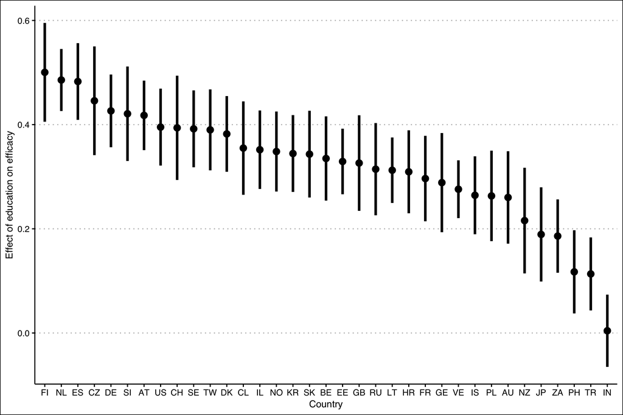

```r
ranef(mlm.2) %>%
    augment(ci.level = 0.95) %>%
    # Different way of writing augment(ranef(mlm.2), ci.level=0.95)
    filter(variable == "educCWC") %>%
    # Keep only random effects for education
    dplyr::select(level, estimate, std.error) %>%
    # Keep only columns identifying the country, the Beta, and SE
    rename(cnt = level) %>%
    mutate(estimate = estimate + fixef(mlm.2)["educCWC"]) %>%
    # Add fixed-effect to deviation from overall slope so as to get
    # the slope in each country
    ggplot(aes(x = reorder(cnt, -estimate),
               y = estimate)) +
    geom_point(size = 3) +
    labs(x = "Country",
         y = "Effect of education on efficacy") +
    theme_clean() +
    geom_errorbar(aes(ymin = estimate - 1.96*std.error,
                      ymax = estimate + 1.96*std.error),
                  linewidth = 1.25,
                  width = 0)
```

You can easily see that you are estimating 3 random effects, as well as a correlation between L2 random effects. R estimates this by default, whereas Stata does not. If you want to suppress this additional parameter from being estimated, it takes a simple modification of the syntax.

```r
mlm.temp <- lmer(poleff ~ 1 + age10CWC + femCWC + educCWC +
                     urbanCWC + inc2CWC + inc3CWC + inc4CWC +
                     cpiCGM + (1 | cnt) + (0 + educCWC | cnt),
                 data = df_issp)
summary(mlm.temp)
```

```
Linear mixed model fit by REML ['lmerMod']
Formula: poleff ~ 1 + age10CWC + femCWC + educCWC + urbanCWC + inc2CWC +
    inc3CWC + inc4CWC + cpiCGM + (1 | cnt) + (0 + educCWC | cnt)
   Data: df_issp

REML criterion at convergence: 78721.8

Scaled residuals:
    Min      1Q  Median      3Q     Max
-4.3000 -0.6728 -0.0105  0.6693  8.7344

Random effects:
 Groups   Name        Variance Std.Dev.
 cnt      (Intercept) 0.07092  0.2663
 cnt.1    educCWC     0.01354  0.1164
 Residual             0.47059  0.6860
Number of obs: 37628, groups:  cnt, 35

Fixed effects:
             Estimate Std. Error t value
(Intercept)  2.963133   0.045171  65.598
age10CWC     0.121850   0.007488  16.272
femCWC      -0.121518   0.007152 -16.991
educCWC      0.322131   0.021301  15.123
urbanCWC     0.050351   0.007811   6.446
inc2CWC      0.066041   0.010131   6.518
inc3CWC      0.131311   0.010303  12.745
inc4CWC      0.251896   0.010704  23.532
cpiCGM       0.298659   0.091659   3.258

Correlation of Fixed Effects:
         (Intr) a10CWC femCWC edcCWC urbCWC in2CWC in3CWC in4CWC
age10CWC  0.000
femCWC    0.000  0.024
educCWC   0.000  0.088 -0.003
urbanCWC  0.000 -0.004 -0.013 -0.052
inc2CWC   0.000  0.025  0.035 -0.036  0.006
inc3CWC   0.000  0.077  0.057 -0.065  0.003  0.515
inc4CWC   0.000  0.078  0.079 -0.105 -0.036  0.510  0.540
cpiCGM    0.000  0.000  0.000  0.000  0.000  0.000  0.000  0.000
```

```r
rm(mlm.temp)
```

# 5 Cross-level interaction

We will extend the specification by adding a predictor for the varying slope of education. The substantive implication of this is that we are now testing a hypothesis: that there is a systematic association between the magnitude of the effect of education on political efficacy, and the level of (perceived) corruption in the country.

```r
mlm.3 <- lmer(poleff ~ 1 + age10CWC + femCWC + educCWC +
                  urbanCWC + inc2CWC + inc3CWC + inc4CWC +
                  cpiCGM + educCWC * cpiCGM + (1 + educCWC | cnt),
              data = df_issp)
summary(mlm.3)
```

```
Linear mixed model fit by REML ['lmerMod']
Formula: poleff ~ 1 + age10CWC + femCWC + educCWC + urbanCWC + inc2CWC +
    inc3CWC + inc4CWC + cpiCGM + educCWC * cpiCGM + (1 + educCWC |      cnt)
   Data: df_issp

REML criterion at convergence: 78717.8

Scaled residuals:
    Min      1Q  Median      3Q     Max
-4.3062 -0.6727 -0.0107  0.6697  8.7669

Random effects:
 Groups   Name        Variance Std.Dev. Corr
 cnt      (Intercept) 0.07092  0.2663
          educCWC     0.01095  0.1046   -0.24
 Residual             0.47059  0.6860
Number of obs: 37628, groups:  cnt, 35

Fixed effects:
                Estimate Std. Error t value
(Intercept)     2.963134   0.045171  65.599
age10CWC        0.121704   0.007487  16.256
femCWC         -0.121565   0.007152 -16.998
educCWC         0.322236   0.019476  16.545
urbanCWC        0.050280   0.007810   6.438
inc2CWC         0.066059   0.010131   6.521
inc3CWC         0.131219   0.010303  12.736
inc4CWC         0.251763   0.010703  23.522
cpiCGM          0.298755   0.091659   3.259
educCWC:cpiCGM  0.108083   0.038942   2.775

Correlation of Fixed Effects:
            (Intr) a10CWC femCWC edcCWC urbCWC in2CWC in3CWC in4CWC cpiCGM
age10CWC     0.000
femCWC       0.000  0.024
educCWC     -0.219  0.096 -0.003
urbanCWC     0.000 -0.004 -0.013 -0.057
inc2CWC      0.000  0.025  0.035 -0.039  0.006
inc3CWC      0.000  0.077  0.057 -0.071  0.003  0.515
inc4CWC      0.000  0.078  0.079 -0.115 -0.036  0.510  0.540
cpiCGM       0.000  0.000  0.000  0.000  0.000  0.000  0.000  0.000
edcCWC:cCGM  0.000 -0.009 -0.005  0.001  0.001  0.000 -0.003 -0.006 -0.222
```

```r
htmlreg(list(mlm.1, mlm.2, mlm.3),
        digits = 3,
        custom.model.names = c("RI", "RI+RS",
                               "RI+RS & pred"),
        caption = "Comparison of 3 multilevel specifications",
        caption.above = TRUE,
        custom.coef.map = list("(Intercept)" = "Intercept",
                               "age10CWC" = "Age (in decades)",
                               "femCWC" = "Gender (woman)",
                               "educCWC" = "Education",
                               "urbanCWC" = "Urban settlement",
                               "inc2CWC" = "2nd income quartile",
                               "inc3CWC" = "3rd income quartile",
                               "inc4CWC" = "4th income quartile",
                               "cpiCGM" = "Corruption perceptions index",
                               "educCWC:cpiCGM" = "Education x Corruption perceptions"), # nolint
        single.row = FALSE,
        inline.css = TRUE,
        html.tag = FALSE,
        head.tag = FALSE,
        body.tag = FALSE)
```

Comparison of 3 multilevel specifications

|  | RI | RI+RS | RI+RS & pred |
| --- | --- | --- | --- |
| Intercept | 2.963*** | 2.963*** | 2.963*** |
|  | (0.045) | (0.045) | (0.045) |
| Age (in decades) | 0.123*** | 0.122*** | 0.122*** |
|  | (0.007) | (0.007) | (0.007) |
| Gender (woman) | -0.120*** | -0.121*** | -0.122*** |
|  | (0.007) | (0.007) | (0.007) |
| Education | 0.319*** | 0.322*** | 0.322*** |
|  | (0.008) | (0.021) | (0.019) |
| Urban settlement | 0.049*** | 0.050*** | 0.050*** |
|  | (0.008) | (0.008) | (0.008) |
| 2nd income quartile | 0.069*** | 0.066*** | 0.066*** |
|  | (0.010) | (0.010) | (0.010) |
| 3rd income quartile | 0.134*** | 0.131*** | 0.131*** |
|  | (0.010) | (0.010) | (0.010) |
| 4th income quartile | 0.258*** | 0.252*** | 0.252*** |
|  | (0.011) | (0.011) | (0.011) |
| Corruption perceptions index | 0.299** | 0.355*** | 0.299** |
|  | (0.092) | (0.089) | (0.092) |
| Education x Corruption perceptions |  |  | 0.108** |
|  |  |  | (0.039) |
| AIC | 78944.009 | 78746.176 | 78745.788 |
| BIC | 79037.899 | 78857.138 | 78865.285 |
| Log Likelihood | -39461.004 | -39360.088 | -39358.894 |
| Num. obs. | 37628 | 37628 | 37628 |
| Num. groups: cnt | 35 | 35 | 35 |
| Var: cnt (Intercept) | 0.071 | 0.072 | 0.071 |
| Var: Residual | 0.474 | 0.471 | 0.471 |
| Var: cnt educCWC |  | 0.014 | 0.011 |
| Cov: cnt (Intercept) educCWC |  | -0.008 | -0.007 |

***p < 0.001; **p < 0.01; *p < 0.05

A few years ago graphically presenting such interaction effects was a more code-demanding task, as it involved manually specifying a range for the moderator variable, constructing a new data set, obtaining predicted values and uncertainty for them, and then plotting these quantities. Thankfully, dedicated packages and canned functions have appeared that can do this for you in a much faster and convenient way.

The `interplot()` function, from the package with the same name, is the most convenient one. It produces a `ggplot2` object, which can then be customized with the set of functions you’re already familiar with.

```r
graph1 <- interplot(mlm.3,
                    var1 = "educCWC", # focal independent variable
                    var2 = "cpiCGM", # moderator variable
                    ci = 0.95)
```

What gets plotted on the Y axis?

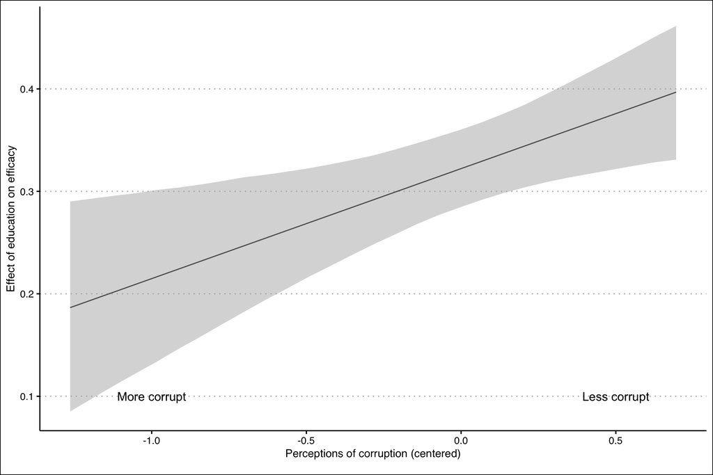

```r
graph1 +
    theme_clean() +
    labs(x = "Perceptions of corruption (centered)",
         y = "Effect of education on efficacy") +
  annotate("text", x = 0.5, y = 0.1, label = "Less corrupt") +
  annotate("text", x = -1, y = 0.1, label = "More corrupt")
```

This makes it clear, though you would be right to doubt that more than a few readers from a non-academic background would be able to interpret this plot. If writing for a less specialized audience (a blog post, or a report), it might be more fruitful to present quantities that are easier to grasp.

Showing predicted values gets us one step closer to the ideal of accessibility.

```r
dat1 <- ggpredict(mlm.3,
                  terms = c("educCWC", "cpiCGM [-1, -0.5, 0, 0.5, 1]"),
                  ci.lvl = 0.95,
                  type = "fe")
```

The first variable in the list of terms in the `ggpredict()` function is the focal independent, while the second one is the moderator variable. Here, I specify distinct values for the moderator. I specify that predictions should be conditional only on fixed effects parameters and their uncertainty.

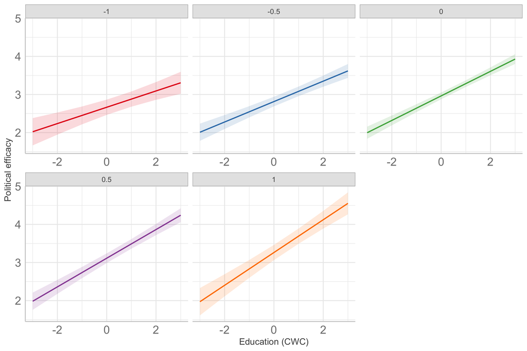

```r
plot(dat1,
     facet = TRUE,
     show.title = FALSE,
     show.x.title = FALSE,
     show.y.title = FALSE) +
  scale_x_continuous(name = "Education (CWC)") +
  scale_y_continuous(name = "Political efficacy") +
  theme(axis.text.x = element_text(size = 14),
        axis.text.y = element_text(size = 14))
```

Unfortunately, using the canned `plot()` function gives you only a minimum amount of flexibility. If you want full control over how the plot looks, you have to access directly the quantities stored in the `dat1` object.

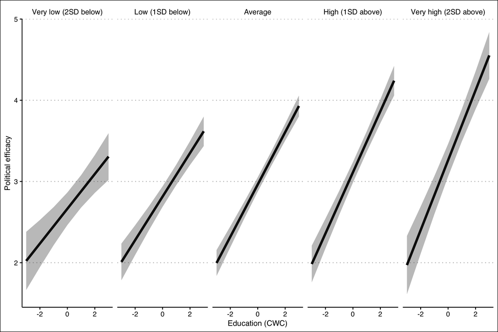

```r
dat1 <- dat1 %>%
    # Recode group label
    mutate(group = as.character(group),
           group = case_when(group=="-1" ~ "Very low (2SD below)",
                             group=="-0.5" ~ "Low (1SD below)",
                             group=="0" ~ "Average",
                             group=="0.5" ~ "High (1SD above)",
                             group=="1" ~ "Very high (2SD above)"),
           # Order the levels, so that in the facet plot these are listed in order.
           group = factor(group, levels = c("Very low (2SD below)",
                                            "Low (1SD below)",
                                            "Average",
                                            "High (1SD above)",
                                            "Very high (2SD above)")))

ggplot(dat1,
       aes(x = x,
           y = predicted)) +
    geom_line(size = 1.5) +
    geom_ribbon(aes(ymin = conf.low,
                    ymax = conf.high),
                alpha = 0.33) +
    # The "ribbon" is the shaded area around the line that denotes
    # uncertainty.
    facet_wrap(.~group, ncol = 5) +
    labs(x = "Education (CWC)",
         y = "Political efficacy") +
    theme_clean()
```

# 6 Model fit

As you can see, the `summary()` function doesn’t give you any indication about the model fit. A set of dedicated functions exist for this.

```r
-2*logLik(mlm.1)
```

```
'log Lik.' 78922.01 (df=11)
```

```r
-2*logLik(mlm.2)
```

```
'log Lik.' 78720.18 (df=13)
```

```r
-2*logLik(mlm.3)
```

```
'log Lik.' 78717.79 (df=14)
```

You also have functions for AIC and BIC (there’s not much sense to have a function for deviance, since it’s computed as $-2 \times logLik$).

```r
AIC(mlm.1)
```

```
[1] 78944.01
```

```r
AIC(mlm.2)
```

```
[1] 78746.18
```

```r
AIC(mlm.3)
```

```
[1] 78745.79
```

```r
BIC(mlm.1)
```

```
[1] 79037.9
```

```r
BIC(mlm.2)
```

```
[1] 78857.14
```

```r
BIC(mlm.3)
```

```
[1] 78865.28
```

For a test of whether the differences in fit are statistically significant, we can turn to the `anova()` function.

```r
anova(mlm.1, mlm.2, mlm.3)
```

```
Data: df_issp
Models:
mlm.1: poleff ~ 1 + age10CWC + femCWC + educCWC + urbanCWC + inc2CWC + inc3CWC + inc4CWC + cpiCGM + (1 | cnt)
mlm.2: poleff ~ 1 + age10CWC + femCWC + educCWC + urbanCWC + inc2CWC + inc3CWC + inc4CWC + cpiCGM + (1 + educCWC | cnt)
mlm.3: poleff ~ 1 + age10CWC + femCWC + educCWC + urbanCWC + inc2CWC + inc3CWC + inc4CWC + cpiCGM + educCWC * cpiCGM + (1 + educCWC | cnt)
      npar   AIC   BIC logLik deviance    Chisq Df Pr(>Chisq)
mlm.1   11 78882 78976 -39430    78860
mlm.2   13 78686 78797 -39330    78660 199.7736  2  < 2.2e-16 ***
mlm.3   14 78681 78801 -39327    78653   7.2758  1   0.006989 **
---
Signif. codes:  0 '***' 0.001 '**' 0.01 '*' 0.05 '.' 0.1 ' ' 1
```

The function automatically re-fits every model in the comparison with **FIML** as opposed to **REML**, and produces a comparison table for the 3 models.

**Questions**:

1. Why is DF=2 for the comparison between Model 1 and Model 2? What are the extra 2 parameters that are estimated in Model 2?
2. Which one is the better fitting model out of the 3?

As an additional specification, let’s also try a model that includes Gini as predictor for the intercept at L1.

```r
mlm.4 <- lmer(poleff ~ 1 + age10CWC + femCWC + educCWC + urbanCWC +
                inc2CWC + inc3CWC + inc4CWC + cpiCGM + gini10CGM +
                educCWC * cpiCGM + (1 + educCWC | cnt),
              data = df_issp)
summary(mlm.4)
```

```
Linear mixed model fit by REML ['lmerMod']
Formula: poleff ~ 1 + age10CWC + femCWC + educCWC + urbanCWC + inc2CWC +
    inc3CWC + inc4CWC + cpiCGM + gini10CGM + educCWC * cpiCGM +
    (1 + educCWC | cnt)
   Data: df_issp

REML criterion at convergence: 78720.2

Scaled residuals:
    Min      1Q  Median      3Q     Max
-4.3046 -0.6724 -0.0107  0.6699  8.7668

Random effects:
 Groups   Name        Variance Std.Dev. Corr
 cnt      (Intercept) 0.07433  0.2726
          educCWC     0.01096  0.1047   -0.29
 Residual             0.47059  0.6860
Number of obs: 37628, groups:  cnt, 35

Fixed effects:
                Estimate Std. Error t value
(Intercept)     2.963146   0.046236  64.088
age10CWC        0.121711   0.007486  16.258
femCWC         -0.121561   0.007151 -16.998
educCWC         0.322283   0.019487  16.539
urbanCWC        0.050263   0.007810   6.436
inc2CWC         0.066038   0.010131   6.519
inc3CWC         0.131197   0.010303  12.734
inc4CWC         0.251749   0.010703  23.522
cpiCGM          0.267702   0.106313   2.518
gini10CGM      -0.064072   0.103099  -0.621
educCWC:cpiCGM  0.108030   0.038964   2.773

Correlation of Fixed Effects:
            (Intr) a10CWC femCWC edcCWC urbCWC in2CWC in3CWC in4CWC cpiCGM
age10CWC     0.000
femCWC       0.000  0.024
educCWC     -0.265  0.096 -0.003
urbanCWC     0.000 -0.004 -0.013 -0.057
inc2CWC      0.000  0.025  0.035 -0.039  0.006
inc3CWC      0.000  0.077  0.057 -0.071  0.003  0.515
inc4CWC      0.000  0.078  0.079 -0.115 -0.036  0.510  0.540
cpiCGM       0.000  0.000  0.001 -0.001  0.000  0.001  0.001  0.000
gini10CGM    0.000  0.000  0.001 -0.003  0.000  0.003  0.001  0.000  0.470
edcCWC:cCGM  0.000 -0.009 -0.005  0.001  0.001  0.000 -0.003 -0.006 -0.235
            g10CGM
age10CWC
femCWC
educCWC
urbanCWC
inc2CWC
inc3CWC
inc4CWC
cpiCGM
gini10CGM
edcCWC:cCGM  0.006
```

Is there maybe a differential effect of Gini on education groups, though?

```r
mlm.5 <- lmer(poleff ~ 1 + age10CWC + femCWC + educCWC + urbanCWC +
                inc2CWC + inc3CWC + inc4CWC + cpiCGM + gini10CGM +
                educCWC * cpiCGM + educCWC * gini10CGM + (1 + educCWC | cnt),
              data = df_issp)
summary(mlm.5)
```

```
Linear mixed model fit by REML ['lmerMod']
Formula: poleff ~ 1 + age10CWC + femCWC + educCWC + urbanCWC + inc2CWC +
    inc3CWC + inc4CWC + cpiCGM + gini10CGM + educCWC * cpiCGM +
    educCWC * gini10CGM + (1 + educCWC | cnt)
   Data: df_issp

REML criterion at convergence: 78715.7

Scaled residuals:
    Min      1Q  Median      3Q     Max
-4.3014 -0.6731 -0.0107  0.6704  8.7645

Random effects:
 Groups   Name        Variance Std.Dev. Corr
 cnt      (Intercept) 0.073097 0.27037
          educCWC     0.008219 0.09066  -0.27
 Residual             0.470588 0.68599
Number of obs: 37628, groups:  cnt, 35

Fixed effects:
                   Estimate Std. Error t value
(Intercept)        2.963145   0.045854  64.621
age10CWC           0.121698   0.007484  16.262
femCWC            -0.121657   0.007151 -17.013
educCWC            0.322894   0.017353  18.607
urbanCWC           0.050237   0.007809   6.433
inc2CWC            0.065813   0.010130   6.497
inc3CWC            0.131157   0.010302  12.732
inc4CWC            0.251965   0.010701  23.546
cpiCGM             0.307931   0.106368   2.895
gini10CGM          0.019013   0.106286   0.179
educCWC:cpiCGM     0.046202   0.039775   1.162
educCWC:gini10CGM -0.124048   0.038856  -3.193

Correlation of Fixed Effects:
            (Intr) a10CWC femCWC edcCWC urbCWC in2CWC in3CWC in4CWC cpiCGM
age10CWC     0.000
femCWC       0.000  0.024
educCWC     -0.235  0.108 -0.003
urbanCWC     0.000 -0.004 -0.013 -0.064
inc2CWC      0.000  0.026  0.035 -0.044  0.006
inc3CWC      0.000  0.077  0.057 -0.080  0.003  0.515
inc4CWC      0.000  0.079  0.079 -0.129 -0.036  0.510  0.540
cpiCGM       0.000  0.000  0.000  0.000  0.000  0.000  0.000  0.000
gini10CGM    0.000  0.000  0.000  0.000  0.000  0.000  0.000  0.000  0.485
edcCWC:cCGM  0.000 -0.010 -0.003 -0.005  0.001  0.005  0.000 -0.006 -0.238
edCWC:10CGM  0.000 -0.001  0.004 -0.012  0.000  0.011  0.004  0.000 -0.118
            g10CGM eCWC:C
age10CWC
femCWC
educCWC
urbanCWC
inc2CWC
inc3CWC
inc4CWC
cpiCGM
gini10CGM
edcCWC:cCGM -0.115
edCWC:10CGM -0.243  0.495
```

Which one fits the data better?

```r
anova(mlm.3, mlm.4, mlm.5)
```

```
Data: df_issp
Models:
mlm.3: poleff ~ 1 + age10CWC + femCWC + educCWC + urbanCWC + inc2CWC + inc3CWC + inc4CWC + cpiCGM + educCWC * cpiCGM + (1 + educCWC | cnt)
mlm.4: poleff ~ 1 + age10CWC + femCWC + educCWC + urbanCWC + inc2CWC + inc3CWC + inc4CWC + cpiCGM + gini10CGM + educCWC * cpiCGM + (1 + educCWC | cnt)
mlm.5: poleff ~ 1 + age10CWC + femCWC + educCWC + urbanCWC + inc2CWC + inc3CWC + inc4CWC + cpiCGM + gini10CGM + educCWC * cpiCGM + educCWC * gini10CGM + (1 + educCWC | cnt)
      npar   AIC   BIC logLik deviance  Chisq Df Pr(>Chisq)
mlm.3   14 78681 78801 -39327    78653
mlm.4   15 78683 78811 -39326    78653 0.3134  1   0.575610
mlm.5   16 78675 78812 -39321    78643 9.7261  1   0.001817 **
---
Signif. codes:  0 '***' 0.001 '**' 0.01 '*' 0.05 '.' 0.1 ' ' 1
```

Try the visualization of the cross-level interaction once more. First, the standard way, through the `plot()` function.

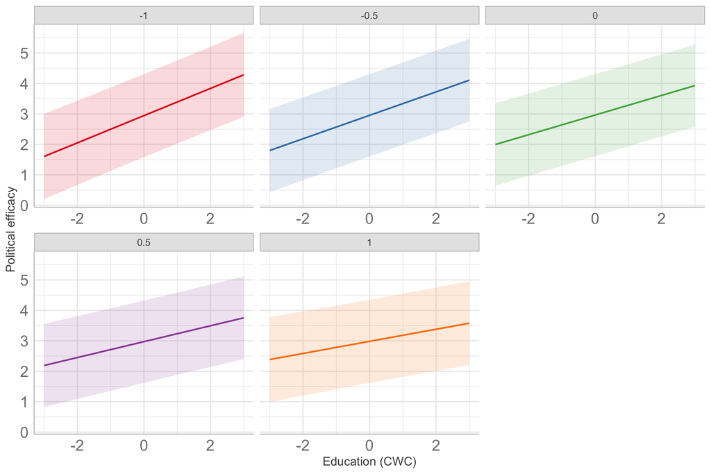

```r
dat2 <- ggpredict(mlm.5,
                  terms = c("educCWC", "gini10CGM [-1, -0.5, 0, 0.5, 1]"),
                  ci.lvl = 0.95,
                  type = "re")

plot(dat2,
     facet = TRUE,
     show.title = FALSE,
     show.x.title = FALSE,
     show.y.title = FALSE) +
  scale_x_continuous(name = "Education (CWC)") +
  scale_y_continuous(name = "Political efficacy") +
  theme(axis.text.x = element_text(size = 14),
        axis.text.y = element_text(size = 14))
```

Finally, try the manual approach, by extracting needed quantities from the `ggpredict` object.

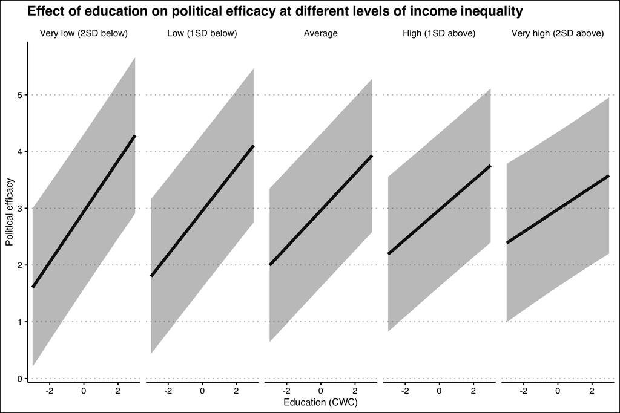

```r
dat2 <- dat2 %>%
  mutate(group = as.character(group),
         group = case_when(group=="-1" ~ "Very low (2SD below)",
                           group=="-0.5" ~ "Low (1SD below)",
                           group=="0" ~ "Average",
                           group=="0.5" ~ "High (1SD above)",
                           group=="1" ~ "Very high (2SD above)"),
         group = factor(group, levels = c("Very low (2SD below)",
                                          "Low (1SD below)",
                                          "Average",
                                          "High (1SD above)",
                                          "Very high (2SD above)")))

ggplot(dat2,
       aes(x = x,
           y = predicted)) +
  geom_line(size = 1.5) +
  geom_ribbon(aes(ymin = conf.low,
                  ymax = conf.high),
              alpha = 0.33) +
  facet_wrap(.~group, ncol = 5) +
  labs(x = "Education (CWC)",
       y = "Political efficacy",
       title = "Effect of education on political efficacy at different levels of income inequality") +
  theme_clean()
```

# 7 Optional home practice

Using the ESS data from yesterday, try out a specification with a random slope for income. After this, use income inequality as a predictor for this slope. Plot the interaction effect using one of the two functions presented above. Of course, do all the needed centering and standardizing procedures before running the models.

# 8 Package versions